# Statistical Methods

One-way ANOVA / Effect Sizes / Contrasts

Fall 2025 | Course PSYC 790  
Jeffrey M. Girard | Lecture 07b

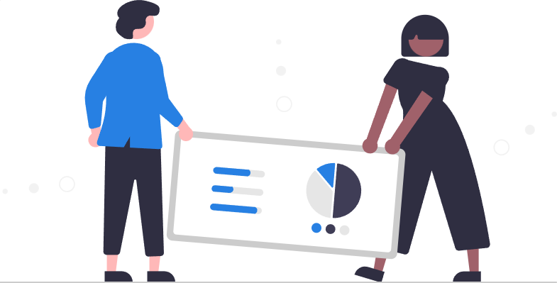

# Introduction

## Rationale

- The $t$-test compares two groups’ population means
- But sometimes we want to compare **three or more** groups
- This is what one-way analysis of variance (ANOVA) does
  - One-way focuses on *one* source of variance (i.e., groups)
  - The one-way ANOVA is for **independent samples**/groups

$$H_0: \text{it is true that } \mu_1=\mu_2=\mu_3 \cdots \\
H_1: \text{it is NOT true that } \mu_1=\mu_2=\mu_3 \cdots$$

## Example dataset

```r
library(tidyverse)
salaries <- read_csv("salaries.csv")
salaries
## # A tibble: 397 × 6
##    rank      discipline yrs.since.phd yrs.service sex    salary
##    <chr>     <chr>              <dbl>       <dbl> <chr>   <dbl>
##  1 Full      Applied               19          18 Male    140.
##  2 Full      Applied               20          16 Male    173.
##  3 Assistant Applied                4           3 Male     79.8
##  4 Full      Applied               45          39 Male    115
##  5 Full      Applied               40          41 Male    142.
##  6 Associate Applied                6           6 Male     97
##  7 Full      Applied               30          23 Male    175
##  8 Full      Applied               45          45 Male    148.
##  9 Full      Applied               21          20 Male    119.
## 10 Full      Applied               18          18 Female  129
## # ℹ 387 more rows
```

- Do the three professor **ranks** have the same mean salary?

## Exploratory analysis

```r
ggplot(salaries, aes(x = rank, y = salary)) +
  ggbeeswarm::geom_quasirandom(
    color = "cornflowerblue",
    size = 3,
    width = 0.25,
    alpha = 1/2
  ) +
  scale_y_continuous() +
  mytheme
```

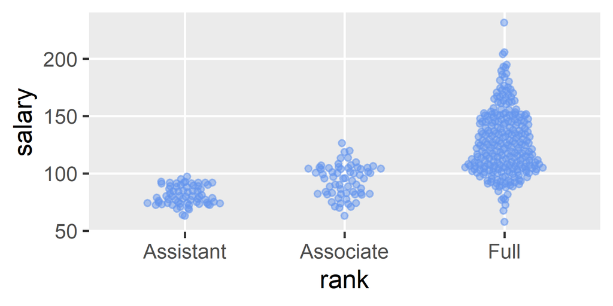

## Total variance

*Across all observations (in all groups), what is the average squared difference between each observation and the global mean (calculated across all observations in all groups)?*

$$\text{Var}(y)=\frac{1}{n}\sum_{i=1}^n(y_i - \bar{y})^2$$

$n$ is the total sample size across all groups

$\bar{y}$ is the global mean of $y$ across all groups

## Sums of squares

- ANOVA uses sums of squares ($SS$) rather than variances
  - $SS$ are the same as variances but don’t divide by $n$
  - They are the **sums** of squared differences (not the means)

$$\color{blue}{\text{SS}_{tot}=\sum_{i=1}^n(y_{i}-\bar{y})^2}$$

$$\text{Var}(y)=\frac{1}{n}\sum_{i=1}^n(y_{i} - \bar{y})^2$$

Using $SS$ yields a nicer interpretation and enables the use of the $F$ distribution

## Between and within groups

- The total variation ($SS_{tot}$) contains two components

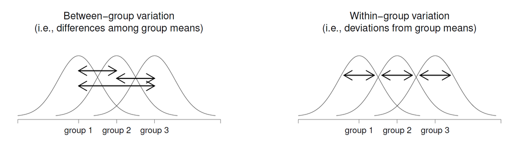

*How different are the three groups/ranks (on average)?*

How different are professors  
in the same group/rank?

## Decomposing the variation

- We can decompose total variation into two components:

**Between-group variation**

$$\text{SS}_b = \sum_{k=1}^gn_k(\bar{y}_k - \bar{y})^2$$

*How far is each group mean $\bar{y}_k$ from the global mean $\bar{y}$?*

**Within-group variation**

$$\text{SS}_w = \sum_{k=1}^g\sum_{i=1}^{n_k}(y_{ik} - \bar{y}_k)^2$$

*How far is each observation $y_{ik}$ from its group mean $\bar{y}_k$?*

Note that the decomposition ensures that $SS_{tot}=SS_b + SS_w$

## Testing for mean differences

- If $H_0$ is true, the groups’ population means are the same
  - Thus, between-group variation $(SS_b)$ should be small
- But how small is small enough? We need to contextualize it
  - ANOVA does so by comparing $SS_b$ to $SS_w$
  - It focuses on the ratio of $SS_b$ to $SS_w$ (i.e., $SS_b/SS_w$)
  - But we need to build in the group and sample sizes
  - Doing so will allow us to calibrate our uncertainty

## Incorporating uncertainty

**Mean Squares Between**

$$\textit{MS}_b = \frac{\textit{SS}_b}{g - 1}$$

**Mean Squares Within**

$$\textit{MS}_w = \frac{\textit{SS}_w}{n - g}$$

The One-way ANOVA Test Statistic
$$F_{obs} = \frac{\textit{MS}_b}{\textit{MS}_w}\\
F_{obs} \sim F(\textit{df}_1 = g - 1, \textit{df}_2 = n - g)$$

$g$ is the number of groups, $n$ is the total sample size

## The F distribution

- The sum of squared normally distributed values will have a $\chi^2$ distribution
- The ratio of two $\chi^2$ distributed variables will have an $F$ distribution

$$x \sim F(\textit{df}_1, \textit{df}_2)$$

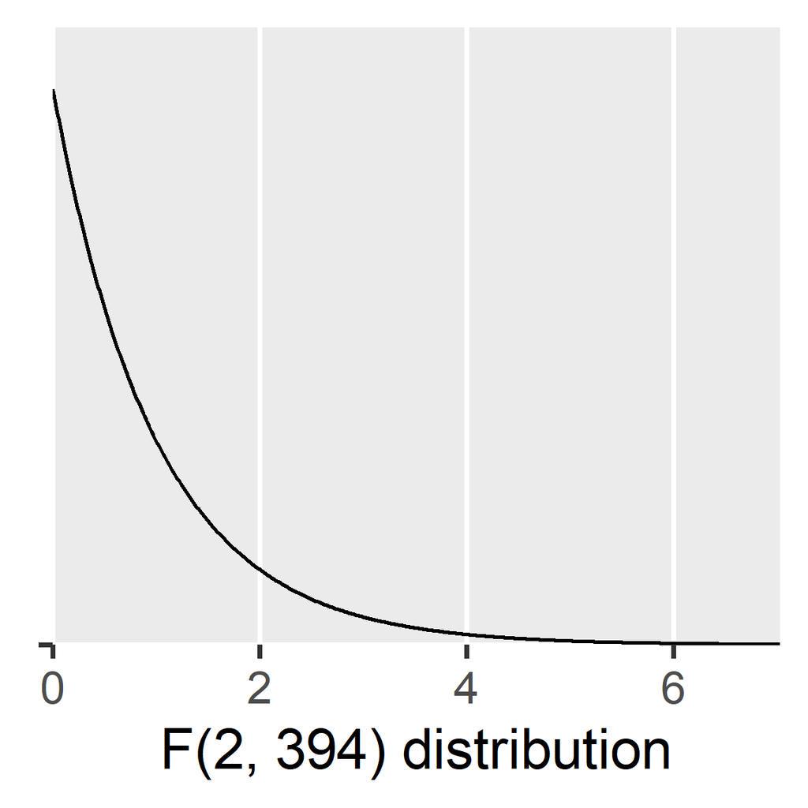

```r
data.frame(df1 = 2, df2 = 394) |>
  ggplot(aes(y = "", dist = dist_f(df1, df2))) +
  stat_dist_slab(fill = NA, color = "black") +
  coord_cartesian(expand = FALSE) +
  scale_color_viridis_c() +
  labs(
    y = NULL,
    x = "F(2, 394) distribution"
  ) +
  mytheme
```

## The df1 parameter

```r
data.frame(df1 = seq(2, 10, 2)) |>
  ggplot(aes(y = "", dist = dist_f(df1, 30), color = df1)) +
  stat_dist_slab(fill = NA, linewidth = 1) +
  coord_cartesian(expand = FALSE) +
  scale_color_viridis_c(breaks = c(2, 6, 10)) +
  labs(
    y = NULL,
    x = "F(df1, 30) distribution",
    color = "df1"
  ) +
  mytheme
```

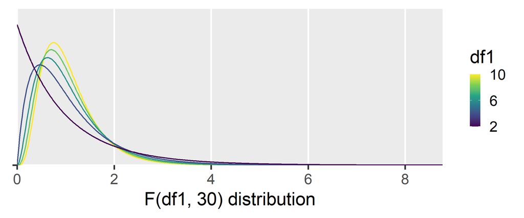

- Higher $\textit{df}_1$ has thinner tails (i.e., lower critical values)

## The df2 parameter

```r
data.frame(df2 = c(10, 20, 30, 40, 50)) |>
  ggplot(aes(y = "", dist = dist_f(10, df2), color = df2)) +
  stat_dist_slab(fill = NA, linewidth = 1) +
  coord_cartesian(expand = FALSE) +
  scale_color_viridis_c(breaks = c(10, 30, 50)) +
  labs(
    y = NULL,
    x = "F(10, df2) distribution",
    color = "df2"
  ) +
  mytheme
```

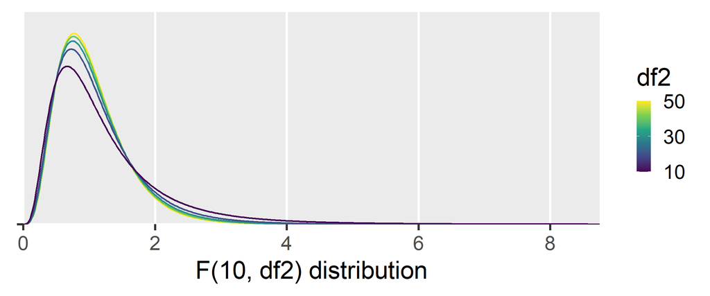

- Higher $\textit{df}_2$ has thinner tails (i.e., lower critical values)

# One-way ANOVA in R

## The aov function

- The `aov()` function will do this math for us

```r
fit <- aov(
  formula = salary ~ rank,
  data = salaries
)
```

```r
summary(fit)
##              Df Sum Sq Mean Sq F value Pr(>F)
## rank          2 143232   71616   128.2 <2e-16 ***
## Residuals   394 220069     559
## ---
## Signif. codes:  0 '***' 0.001 '**' 0.01 '*' 0.05 '.' 0.1 ' ' 1
```

```r
# Critical value (to compare to F_obs = 128.2)
qf(.975, df1 = 2, df2 = 394)
## [1] 3.723634
```

## Prettier output

```r
library(easystats)
model_parameters(fit)
## Parameter | Sum_Squares |  df | Mean_Square |      F |      p
## -------------------------------------------------------------
## rank      |    1.43e+05 |   2 |    71615.88 | 128.22 | < .001
## Residuals |    2.20e+05 | 394 |      558.55 |        |
##
## Anova Table (Type 1 tests)
```

*We used a one-way ANOVA to compare the mean salaries of Assistant, Associate, and Full professors and rejected the null hypothesis that these three groups have the same mean, $F(2,394)=128.22$, $p<.001$.*

## Estimating group means

- We can also estimate the model-implied group means

```r
gmeans <- estimate_means(fit, by = "rank")
gmeans
## Estimated Marginal Means
##
## rank      |   Mean |   SE |           95% CI | t(394)
## -----------------------------------------------------
## Assistant |  80.78 | 2.89 | [ 75.10,  86.45] |  27.98
## Associate |  93.88 | 2.95 | [ 88.07,  99.68] |  31.78
## Full      | 126.77 | 1.45 | [123.92, 129.62] |  87.48
##
## Variable predicted: salary
## Predictors modulated: rank
```

Note that this function requires the {emmeans} package to be installed

## Plotting group means

```r
plot(gmeans)
```

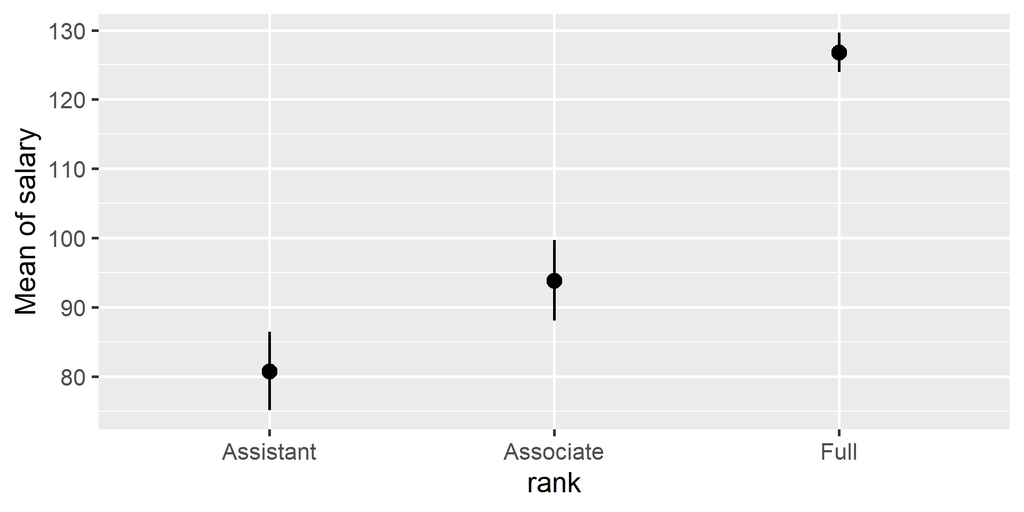

## An effect size for One-way ANOVA

- We conclude that $H_0$ is wrong, but *how wrong* was it?
- **How much of the total variation was between groups?**

$$\eta^2 = \frac{SS_b}{SS_{tot}}$$

- If $\eta^2=0$, then none of the variation was between groups
- If $\eta^2=1$, then all of the variation was between groups

## Application and interpretation

```r
ss_b <- 143232
ss_w <- 220069
ss_tot <- ss_b + ss_w

ss_b / ss_tot
## [1] 0.3942516
```

```r
eta_squared(fit)
## # Effect Size for ANOVA
##
## Parameter | Eta2 |       95% CI
## -------------------------------
## rank      | 0.39 | [0.33, 1.00]
##
## - One-sided CIs: upper bound fixed at [1.00].
```

- So 39% of the variation in salary was between groups/ranks

# Post-hoc Tests

## Many ways to reject the null

- Recall that our null hypothesis is that $\mu_1=\mu_2=\mu_3$

| Possibility | $\mu_1=\mu_2$ | $\mu_1=\mu_3$ | $\mu_2=\mu_3$ | Hypothesis |
| --- | --- | --- | --- | --- |
| 1 | TRUE | TRUE | TRUE | null |
| 2 | - | TRUE | TRUE | alternative |
| 3 | TRUE | - | TRUE | alternative |
| 4 | TRUE | TRUE | - | alternative |
| 5 | TRUE | - | - | alternative |
| 6 | - | TRUE | - | alternative |
| 7 | - | - | TRUE | alternative |
| 8 | - | - | - | alternative |

- Thus, if we reject the null, we don’t know exactly why…

## Pairwise $t$-tests

- To figure it out, we can run a $t$-test for each pair of groups
  - These are called “post hoc” (Latin for “after that”) tests

$$\mu_1=\mu_2 \qquad \mu_1=\mu_3 \qquad \mu_2=\mu_3$$

- There are two main challenges with this approach
  - It will be a hassle to run all these tests as $g$ increases
  - Running many tests will increase the Type I Error rate

## Addressing the challenges

- For the first challenge, we will use programming
  - We will use R functions to do all the work for us
- For the second challenge, we will use two approaches
  - **Gating:** only run post-hoc tests if ANOVA is significant
  - $p$-value adjustment: increase $p$ based on # of tests run
- We want to keep the overall (“familywise”) error rate at $\alpha$
  - We will learn two common adjustment approaches

## Bonferroni correction

- Multiply each $p$ by the number of tests run ($m$)

$$p' = p \times m$$

| raw $p$ | $m$ | Bonferroni $p'$ |
| --- | --- | --- |
| .001 *** | 5 | .005 ** |
| .005 ** | 5 | .025 * |
| .019 * | 5 | .095 |
| .022 * | 5 | .110 |
| .103 | 5 | .515 |

Bonferonni is simple but very conservative

## Holm correction

- Pretend you do the tests from smallest to largest $p$-value
- Take the larger of $(p'_j=j\times p_j)$ and $(p'_{j+1})$

| raw $p$ | rank $j$ | $p\times j$ | Holm $p'$ |
| --- | --- | --- | --- |
| .001 *** | 5 | .005 | .005 ** |
| .005 ** | 4 | .020 | .020 * |
| .019 * | 3 | .057 | .057 |
| .022 * | 2 | .044 | .057 |
| .103 | 1 | .103 | .103 |

Holm is complicated but more powerful

## Post-hoc tests in R

```r
estimate_contrasts(
  model = fit,
  contrast = "rank",
  method = "pairwise",
  p_adjust = "bonferroni"
)
## Marginal Contrasts Analysis
##
## Level1    | Level2    | Difference |   SE |         95% CI | t(394) |      p
## ----------------------------------------------------------------------------
## Associate | Assistant |      13.10 | 4.13 | [ 4.98, 21.22] |   3.17 |  0.005
## Full      | Assistant |      46.00 | 3.23 | [39.64, 52.35] |  14.24 | < .001
## Full      | Associate |      32.90 | 3.29 | [26.43, 39.36] |  10.00 | < .001
##
## Variable predicted: salary
## Predictors contrasted: rank
## p-value adjustment method: Bonferroni
```

## Adjustment in R

```r
estimate_contrasts(
  model = fit,
  contrast = "rank",
  method = "pairwise",
  p_adjust = "holm" # change the method here
)
## Marginal Contrasts Analysis
##
## Level1    | Level2    | Difference |   SE |         95% CI | t(394) |      p
## ----------------------------------------------------------------------------
## Associate | Assistant |      13.10 | 4.13 | [ 4.98, 21.22] |   3.17 |  0.002
## Full      | Assistant |      46.00 | 3.23 | [39.64, 52.35] |  14.24 | < .001
## Full      | Associate |      32.90 | 3.29 | [26.43, 39.36] |  10.00 | < .001
##
## Variable predicted: salary
## Predictors contrasted: rank
## p-value adjustment method: Holm (1979)
```